# Bakery Order Model

PR

February 03, 2026

```r
library(tidyverse)
library(MASS)
library(splines)
library(here)
model_data <- here("data","model","model_data_2.3.rds") %>% read_rds()
bakery_data <- here("data","processed","bakery_totals_by_date.rds") %>% read_rds() %>%
  mutate(
    month_day = as.Date(paste0("2000-", format(date, "%m-%d"))),
    last_sale_min_to_close_cat = case_when(
      last_sale_min_to_close < 100 ~ "<100",
      last_sale_min_to_close < 200 ~ "100-200",
      last_sale_min_to_close < 300 ~ "200-300",
      TRUE ~ ">300"
    ) %>% factor(levels = c("<100","100-200","200-300",">300"))
  )
```

# 1 Multipliers

```r
multipliers <- model_data %>% group_by(weather_category) %>%
  summarize(
    multiplier = (sum(num_items) / sum(num_items_pred)) %>% round(2)
  )
multipliers
```

| weather_category | multiplier |
| --- | --- |
| bad_weather | 0.90 |
| neutral_weather | 1.04 |
| good_weather | 1.07 |

# 2 Data Overview

## 2.1 Number of items per day by category

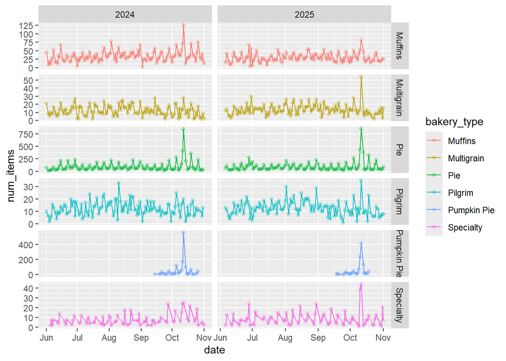

```r
bakery_data %>% ggplot(aes(date, num_items, color = bakery_type)) +
  geom_point(alpha = 0.3) +
  geom_line() +
  facet_grid(bakery_type ~ year, scales = "free")
```

## 2.2 Raw counts

```r
bakery_data %>% count(bakery_type, weekday) %>%
  pivot_wider(
    names_from = weekday,
    values_from = n
  )
```

| bakery_type | Sun | Mon | Tue | Wed | Thu | Fri | Sat |
| --- | --- | --- | --- | --- | --- | --- | --- |
| Muffins | 2 | 41 | 43 | 43 | 43 | 44 | 44 |
| Multigrain | 2 | 43 | 41 | 42 | 43 | 44 | 44 |
| Pie | 2 | 43 | 42 | 43 | 43 | 43 | 44 |
| Pilgrim | 2 | 41 | 42 | 43 | 42 | 43 | 44 |
| Pumpkin Pie | NA | 8 | 7 | 6 | 11 | 11 | 12 |
| Specialty | 1 | 3 | NA | 42 | 42 | 44 | 33 |

```r
bakery_data %>% count(bakery_type, year) %>%
  pivot_wider(
    names_from = year,
    values_from = n
  )
```

| bakery_type | 2024 | 2025 |
| --- | --- | --- |
| Muffins | 132 | 128 |
| Multigrain | 132 | 127 |
| Pie | 131 | 129 |
| Pilgrim | 130 | 127 |
| Pumpkin Pie | 31 | 24 |
| Specialty | 78 | 87 |

```r
bakery_data %>% group_by(bakery_type) %>%
  summarize(
    ave_per_day = mean(num_items),
    st_per_day = sd(num_items),
    total = n()
  )
```

| bakery_type | ave_per_day | st_per_day | total |
| --- | --- | --- | --- |
| Muffins | 31.623077 | 15.030350 | 260 |
| Multigrain | 12.745174 | 6.491253 | 259 |
| Pie | 90.761538 | 96.236501 | 260 |
| Pilgrim | 12.404669 | 5.656134 | 257 |
| Pumpkin Pie | 50.581818 | 98.018081 | 55 |
| Specialty | 8.442424 | 6.582823 | 165 |

```r
bakery_data %>% group_by(day_category_both) %>%
  summarize(
    ave_per_day = mean(num_items),
    st_per_day = sd(num_items),
    total = n()
  )
```

| day_category_both | ave_per_day | st_per_day | total |
| --- | --- | --- | --- |
| Weekday | 23.43202 | 21.68317 | 912 |
| Saturday | 55.33889 | 67.93195 | 180 |
| PA_day | 30.76471 | 32.54756 | 51 |
| Holiday | 54.68750 | 85.36995 | 32 |
| Near_Holiday | 67.15000 | 99.88392 | 40 |
| Sat_Holiday_Weekend | 125.56098 | 205.73357 | 41 |

## 2.3 Plot of Num_items by type

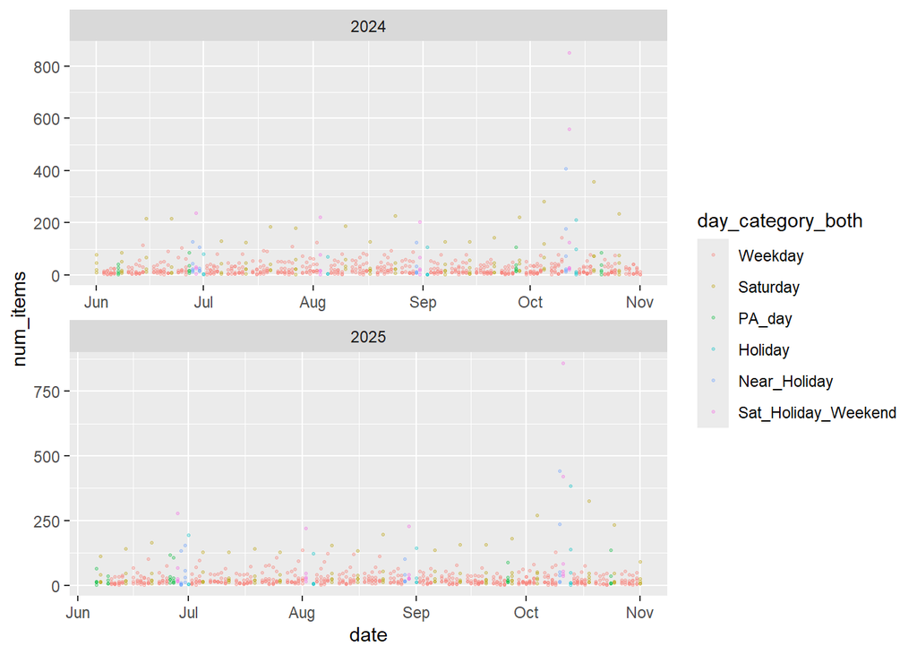

```r
bakery_data %>% ggplot(aes(date, num_items, color = day_category_both)) +
  geom_point(alpha = 0.3, size = 0.5) +
  facet_wrap(~year, scales = "free", ncol = 1)
```

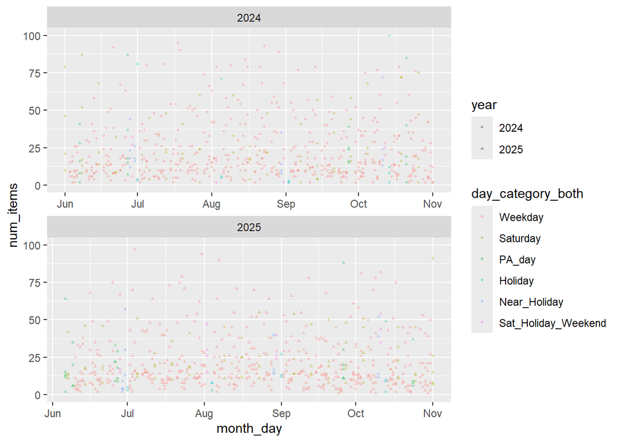

```r
bakery_data %>% ggplot(aes(month_day, num_items, color = day_category_both, shape = year)) +
  geom_point(alpha = 0.3, size = 0.8) +
  facet_wrap(~year, scales = "free", ncol = 1) +
  scale_y_continuous(limits = c(0,100))
```

## 2.4 Raw distributions

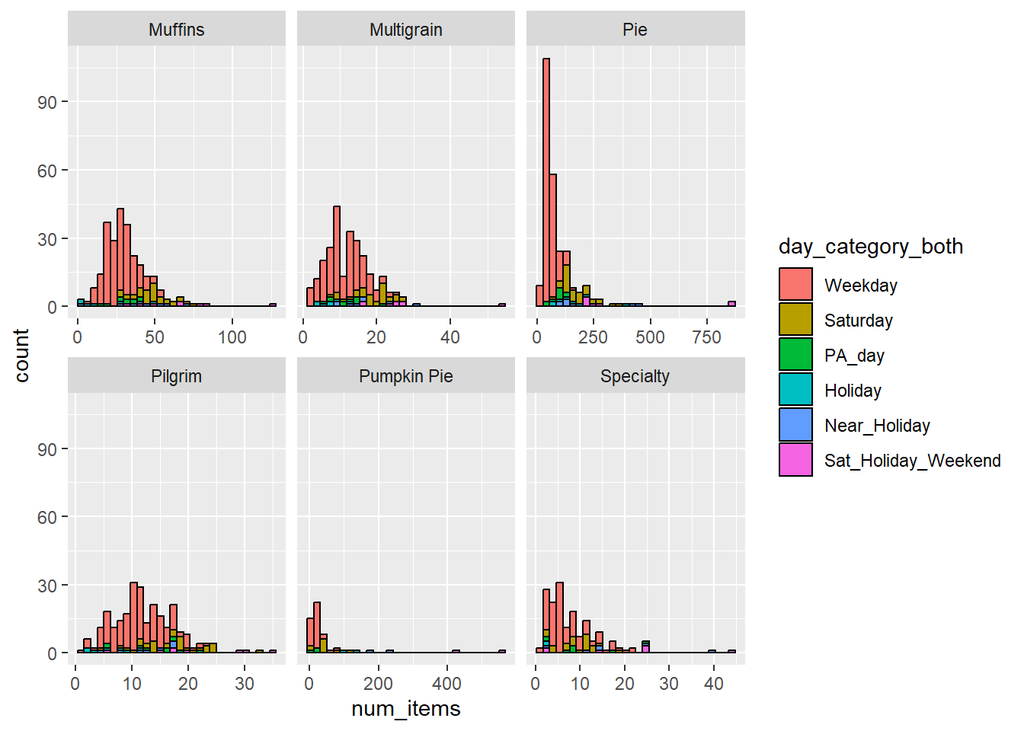

```r
bakery_data %>% ggplot(aes(num_items, fill = day_category_both)) +
  geom_histogram(color = "black") +
  facet_wrap(~bakery_type, scales = "free_x")
```

# 3 Next steps

1. make baseline model with out last_sale_min_to_close using all bakery items
2. plot residuals vs last_sale_min_to_close - see where cut off is to define sold_out_flag (probable)
3. finalize base model with all bakery items using sold_out_flag
4. Define individual models - Muffins, Multigrain, Pie, Pilgrim, Specialty

# 4 Models

Baseline will use Negative Binomial GLM on all bakery items

- glm.nb() → handles overdispersion automatically
- bakery_type → absorbs scale differences across items
- No sold-out variable yet → clean baseline
- Same seasonal structure you already validated

## 4.1 Baseline

```r
library(MASS)
library(splines)

baseline_model_nb <-
  glm.nb(
    num_items ~
      ns(season_week, df = 2) +
      day_category_both +
      PYO_strawberry +
      Thanksgiving_weekend +
      bakery_type,
    data = bakery_data
  )

summary(baseline_model_nb)
```

```
##
## Call:
## glm.nb(formula = num_items ~ ns(season_week, df = 2) + day_category_both +
##     PYO_strawberry + Thanksgiving_weekend + bakery_type, data = bakery_data,
##     init.theta = 6.097342679, link = log)
##
## Coefficients:
##                                      Estimate Std. Error z value Pr(>|z|)
## (Intercept)                           2.83333    0.05930  47.778  < 2e-16 ***
## ns(season_week, df = 2)1              0.90101    0.11237   8.018 1.07e-15 ***
## ns(season_week, df = 2)2             -0.17631    0.04829  -3.651 0.000262 ***
## day_category_bothSaturday             0.69944    0.03699  18.909  < 2e-16 ***
## day_category_bothPA_day               0.34275    0.06882   4.981 6.34e-07 ***
## day_category_bothHoliday             -0.13499    0.08987  -1.502 0.133065
## day_category_bothNear_Holiday         0.39870    0.07899   5.048 4.48e-07 ***
## day_category_bothSat_Holiday_Weekend  0.88611    0.07543  11.747  < 2e-16 ***
## PYO_strawberryTRUE                    0.22324    0.05183   4.307 1.65e-05 ***
## Thanksgiving_weekendTRUE              1.19808    0.09311  12.867  < 2e-16 ***
## bakery_typeMultigrain                -0.91116    0.04148 -21.964  < 2e-16 ***
## bakery_typePie                        0.91693    0.03804  24.102  < 2e-16 ***
## bakery_typePilgrim                   -0.92792    0.04163 -22.292  < 2e-16 ***
## bakery_typePumpkin Pie               -0.08676    0.06825  -1.271 0.203681
## bakery_typeSpecialty                 -1.38181    0.05043 -27.402  < 2e-16 ***
## ---
## Signif. codes:  0 '***' 0.001 '**' 0.01 '*' 0.05 '.' 0.1 ' ' 1
##
## (Dispersion parameter for Negative Binomial(6.0973) family taken to be 1)
##
##     Null deviance: 7166.3  on 1255  degrees of freedom
## Residual deviance: 1277.1  on 1241  degrees of freedom
## AIC: 9226.4
##
## Number of Fisher Scoring iterations: 1
##
##
##               Theta:  6.097
##           Std. Err.:  0.315
##
##  2 x log-likelihood:  -9194.392
```

## 4.2 Cleaned categories

No go

```r
library(MASS)
library(splines)

baseline_model_nb <-
  glm.nb(
    num_items ~
      ns(season_week, df = 2) +
      day_category_cleaned +
      PYO_strawberry +
      Thanksgiving_weekend +
      bakery_type,
    data = bakery_data
  )

summary(baseline_model_nb)
```

```
##
## Call:
## glm.nb(formula = num_items ~ ns(season_week, df = 2) + day_category_cleaned +
##     PYO_strawberry + Thanksgiving_weekend + bakery_type, data = bakery_data,
##     init.theta = 6.01056639, link = log)
##
## Coefficients:
##                                         Estimate Std. Error z value Pr(>|z|)
## (Intercept)                              2.86510    0.05915  48.437  < 2e-16
## ns(season_week, df = 2)1                 0.83590    0.11179   7.477 7.59e-14
## ns(season_week, df = 2)2                -0.15811    0.04835  -3.270  0.00108
## day_category_cleanedSaturday             0.69719    0.03719  18.744  < 2e-16
## day_category_cleanedHoliday_or_PA        0.17447    0.05580   3.127  0.00177
## day_category_cleanedNear_Holiday         0.43598    0.07864   5.544 2.96e-08
## day_category_cleanedSat_Holiday_Weekend  0.93018    0.07511  12.385  < 2e-16
## PYO_strawberryTRUE                       0.21295    0.05206   4.090 4.31e-05
## Thanksgiving_weekendTRUE                 1.07864    0.08848  12.191  < 2e-16
## bakery_typeMultigrain                   -0.91290    0.04169 -21.898  < 2e-16
## bakery_typePie                           0.90707    0.03827  23.699  < 2e-16
## bakery_typePilgrim                      -0.92794    0.04182 -22.186  < 2e-16
## bakery_typePumpkin Pie                  -0.08710    0.06864  -1.269  0.20447
## bakery_typeSpecialty                    -1.37602    0.05061 -27.189  < 2e-16
##
## (Intercept)                             ***
## ns(season_week, df = 2)1                ***
## ns(season_week, df = 2)2                **
## day_category_cleanedSaturday            ***
## day_category_cleanedHoliday_or_PA       **
## day_category_cleanedNear_Holiday        ***
## day_category_cleanedSat_Holiday_Weekend ***
## PYO_strawberryTRUE                      ***
## Thanksgiving_weekendTRUE                ***
## bakery_typeMultigrain                   ***
## bakery_typePie                          ***
## bakery_typePilgrim                      ***
## bakery_typePumpkin Pie
## bakery_typeSpecialty                    ***
## ---
## Signif. codes:  0 '***' 0.001 '**' 0.01 '*' 0.05 '.' 0.1 ' ' 1
##
## (Dispersion parameter for Negative Binomial(6.0106) family taken to be 1)
##
##     Null deviance: 7082.9  on 1255  degrees of freedom
## Residual deviance: 1282.3  on 1242  degrees of freedom
## AIC: 9243
##
## Number of Fisher Scoring iterations: 1
##
##
##               Theta:  6.011
##           Std. Err.:  0.311
##
##  2 x log-likelihood:  -9213.017
```

## 4.3 Baseline Residuals

```r
baseline_model_nb <-
  glm.nb(
    num_items ~
      ns(season_week, df = 2) +
      day_category_both +
      PYO_strawberry +
      Thanksgiving_weekend +
      bakery_type,
    data = bakery_data
  )

bakery_data <- bakery_data %>%
  mutate(
    resid_nb = residuals(baseline_model_nb, type = "pearson"),
    sold_out_flag = last_sale_min_to_close >= 300
  )
```

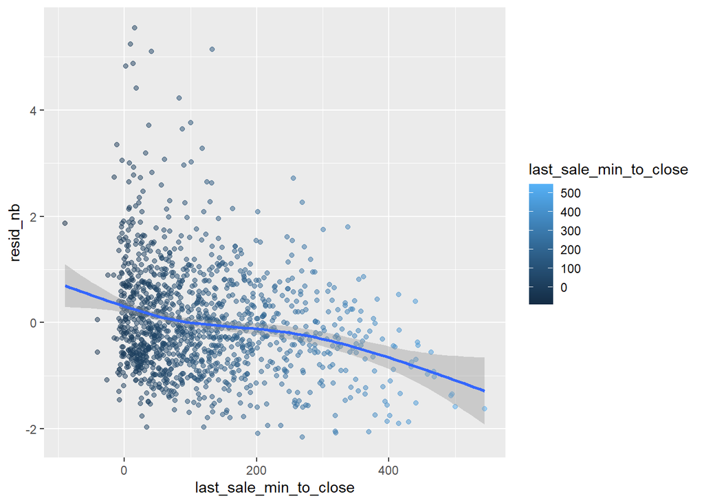

```r
ggplot(bakery_data,
       aes(last_sale_min_to_close, resid_nb, color = last_sale_min_to_close)) +
  geom_point(alpha = 0.5) +
  geom_smooth()
```

This graph shows good basis to use 300 minutes (5 hours before close) for last sale as evidence for selling out.

Scree test - notice elbow in curve

```r
bakery_data %>% count(bakery_type, sold_out_flag) %>%
  pivot_wider(
    names_from = bakery_type,
    values_from = n
  )
```

| sold_out_flag | Muffins | Multigrain | Pie | Pilgrim | Pumpkin Pie | Specialty |
| --- | --- | --- | --- | --- | --- | --- |
| FALSE | 254 | 239 | 260 | 228 | 51 | 124 |
| TRUE | 6 | 20 | NA | 29 | 4 | 41 |

QUestion for John:

- Do these numbers track?

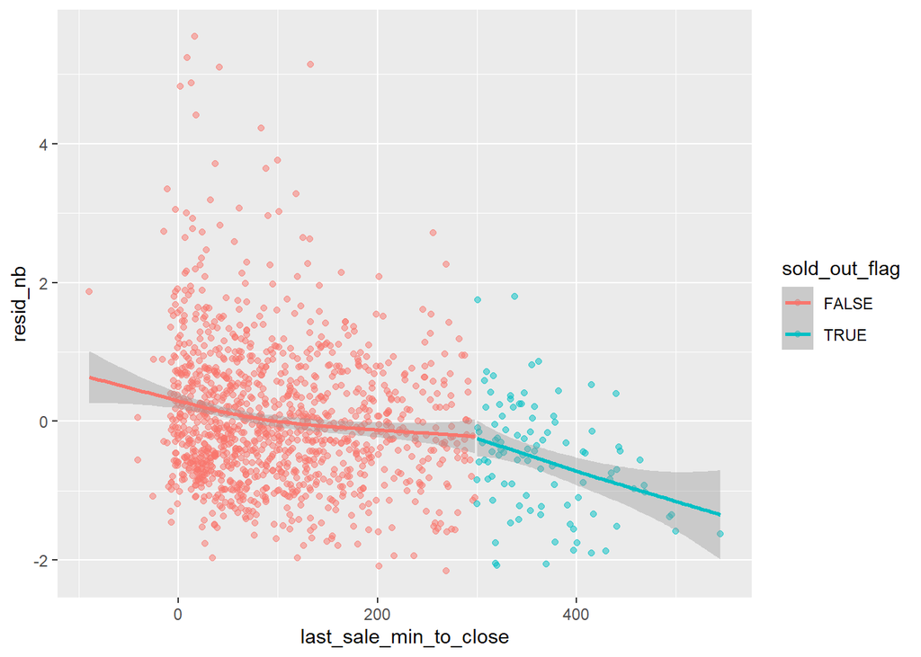

```r
ggplot(bakery_data,
       aes(last_sale_min_to_close, resid_nb, color = sold_out_flag)) +
  geom_point(alpha = 0.5) +
  geom_smooth()
```

The following just looks like noise to me:

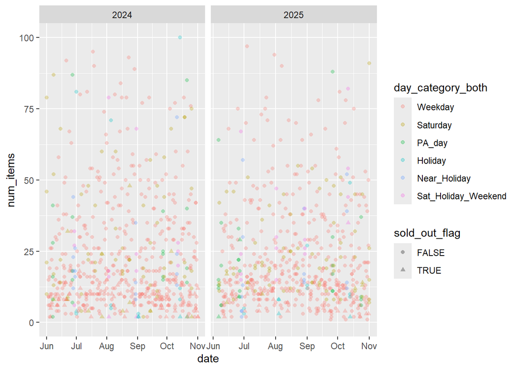

```r
ggplot(bakery_data,
       aes(date, num_items, color = day_category_both, shape = sold_out_flag, alpha = sold_out_flag)) +
  geom_point(alpha = 0.3) +
  facet_wrap(~year, scales = "free_x") +
  scale_y_continuous(limits = c(0,100))
```

```r
bakery_data %>%
  group_by(sold_out_flag) %>%
  summarize(
    mean_resid = mean(resid_nb, na.rm = TRUE),
    median_resid = median(resid_nb, na.rm = TRUE),
    n = n()
  )
```

| sold_out_flag | mean_resid | median_resid | n |
| --- | --- | --- | --- |
| FALSE | 0.05356359 | -0.09780898 | 1156 |
| TRUE | -0.55135038 | -0.48805223 | 100 |

## 4.4 Future improvments

sold_out_flag to sold_out_flag2 whereby it registers as sold out either:

- last sale was 300 minutes before close, OR
- sales were above median and 50 minutes before close.

We may be missing sold_out_flag on high sales days